# bayonne-15

**Processing Proto-agents and Proto-patients:**

**Eye-tracking and EEG evidence in Spanish**

Author:

Marta Sánchez-López

Supervisors:

Prof. Itziar Laka

Dr. Mikel Santesteban

Gogo Elebiduna

Universidad del País Vasco/Euskal Herriko Unibertsitatea (UPV/EHU)

[figure not shown]

[figure not shown]

# Index

- Introduction
- Experiment 1
- Experiment 2
- Experiments 3 and 4
- General Discussion
- Conclusion
- References

# Introduction

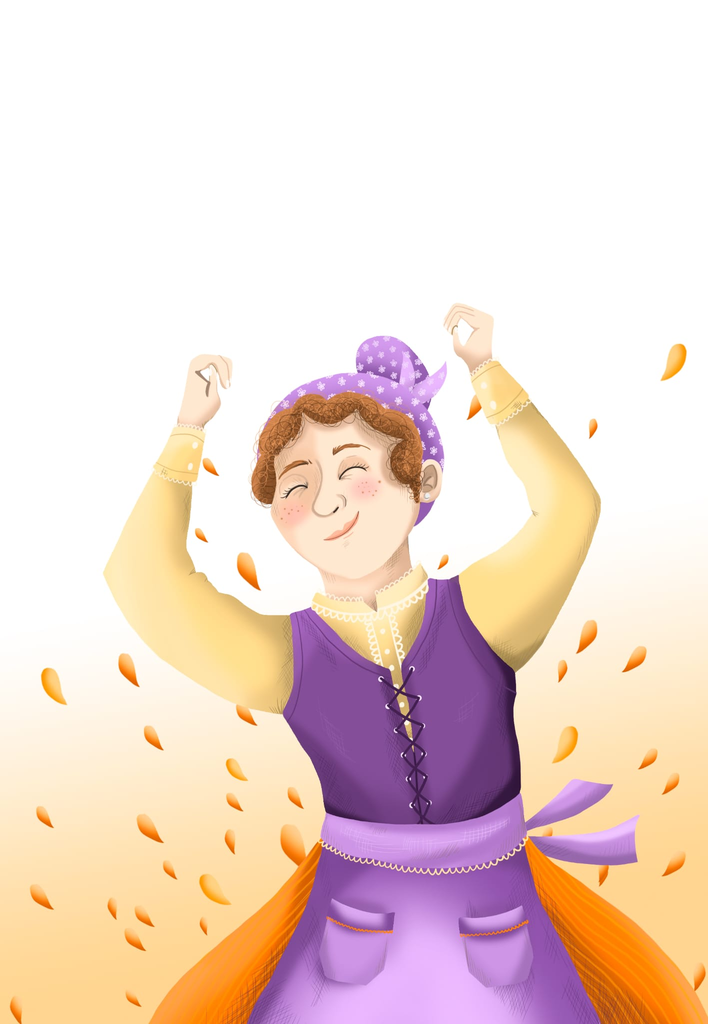

Event roles

**The girl** danced.

⇩

Agent

**The girl** enjoyed.

⇩

Experiencer

Thematic role list approaches

Fillmore (1968)

Proto-role approach

Dowty (1991)

The Theta System

Reinhart (2000)

The Role and Reference Grammar

Foley & Van Valin (1984); Van Valin & LaPolla (1997)

**Thematic role list approaches**

Fillmore (1968)

Thematic roles are:

- **discrete** categories
- **primitive** categories
- **hierarchically** organized

**Thematic role list approaches**

Fillmore (1968) proposed a first list of roles,

*agentive, instrumental, dative, factitive, locative,* and *objective*

and the first thematic hierarchy for subject selection:

**Agent > Instrument > Objective**

**Thematic role list approaches**

Agent > Experiencer > Instrument > Object > Source/Goal/Location > Time

Fillmore (1971)

Agent > Experiencer > Theme

Belletti & Rizzi (1988)

Actor > Patient/Benefactive > Theme > Goal/Source/Location

Jackendoff (1990)

**Thematic role list approaches**

- No agreement on the number of event role categories.
- No agreement on the boundaries of them.

Dowty (1991); Levin & Rappaport Hovav (2005)

**Verbs selecting experiencer role**

Perceptual verbs

Psychological verbs

*see, hear*

Chapin (1967)

*frighten, amuse*

Postal (1970)

→

*frighten*-type verbs

*fear, love*

Belletti & Rizzi (1988)

→

*fear*-type verbs

↓

*Psychological Verb Hypothesis*

**Psychological Verb Hypothesis**

Belletti & Rizzi (1988)

↓

*fear*-type verbs - experiencer-theme

John feared Mary.

*frighten*-type verbs - theme-experiencer

Mary frightened John.

Agent > Experiencer > Theme

**Non-psychological Verb Hypothesis**

Grimshaw (1990)

↓

*fear*-type verbs - experiencer-theme

*frighten*-type verbs - agent/cause-experiencer

**Psychological Verb Hypothesis**

Belletti & Rizzi (1988)

↓

*fear*-type verbs - experiencer-theme

John feared Mary.

*frighten*-type verbs - **theme**-experiencer

Mary frightened John.

Agent > Experiencer > Theme

**Non-psychological Verb Hypothesis**

Grimshaw (1990)

↓

*fear*-type verbs - experiencer-theme

*frighten*-type verbs - **agent/cause**-experiencer

**The proto-role approach**

Dowty (1991)

Proto-agent

Proto-patient

- Volition
- Sentience
- Causation
- Movement
- Undergoes a change
- Incremental theme
- Causally affected
- Stationary

**The proto-role approach**

Dowty (1991)

Argument Selection Principle

↓

proto-roles as **non-discrete categories**

**The proto-role approach**

Dowty (1991)

**Mary** built a house

↓

- Volition
- Sentience
- Causation
- Movement

↓

No-proto-agent entailments

**The proto-role approach**

Dowty (1991)

**Mary** feared dogs

↓

- Sentience

↓

No-proto-agent entailments

**The proto-role approach**

Dowty (1991)

**Mary** frightened **John**

↓

- Sentience
- Volition
- Causation

↓

- Sentience

**Experimental evidence on event roles**

Agents and patients exhibit distinct processing correlates.

Rissman & Majid (2019)

Humans have an attentional bias toward agents.

Gómez-Vidal et al. (2022)

Humans prefer to assign the agent role to the first ambiguous noun phrase, causing an N400 effect when encountering a patient.

Haupt et al. (2008); Sauppe et al. (2023); Isasi-Isasmendi et al. (2024)

**Experimental evidence on event roles**

Experiencer role

*Frighten*-type verbs involve higher processing cost than *fear*-type verbs in English.

Do & Kaiser (2021); Wilson & Dillon (2022)

*Frighten*-type verbs involve higher processing cost than agent-patient verbs in Spanish and German.

Gattei et al. (2015); Gattei et al. (2017); Bornkessel (2002); Bornkessel et al. (2003)

**Experimental evidence on event roles**

Experiencer role

Psychological Verb Hypothesis

Belletti & Rizzi (1988)

*Frighten*-type verbs - theme-experiencer

Agent > Experiencer > Theme

→

**Misalignment**

*Fear*-type verbs - experiencer-theme

Agent-patient verbs - agent-patient

→

**Alignment**

# Experiment 1

- RQ 1: Do psychological verbs elicit processing specificities?
- RQ 2: Do experiencers exhibit specific processing correlates?

RQ 1: Do psychological verbs elicit processing specificities?

Mary saw John

Mary feared John

Mary frightened John

Psychological Verbs

→

Psychological Verbs

→

Perceptual Verbs

→

**Psychological Verb Hypothesis**

*fear*-type = *frighten*-type

*fear*-type ≠ perceptual

**Non-Psychological Verb Hypothesis**

→

experiencer-theme

→

experiencer-theme

→

agent-experiencer

*fear*-type ≠ *frighten*-type

*fear*-type = perceptual

RQ 2: Do experiencers exhibit specific processing correlates?

Mary frightened John

Mary hit John

**Experiencer Role Hypothesis**

Agent-experiencer

→

Agent-patient

→

*frighten*-type = agent-patient

**Proto-Role Hypothesis**

→

proto-agent-proto-agent

→

proto-agent-proto-patient

*frighten*-type ≠ agent-patient

**Methods of Experiment 1**

50 Spanish native speakers

Eye-tracking reading experiment

40 experimental items and 80 fillers

2x2 repeated measure design

→

Verb Type

Argument Structure Type

Conditions

Sentence Regions

Verb

Argument

Subject

Verb

Object

Post-object

Last-word

Type

Structure

Region

Region

Region

Region

Region

Psych

Experiencer-  
theme

La cantante

**desea**

al poeta

durante el  
recital de

poesía.

Non-psych

Experiencer-  
theme

La cantante

**contempla**

al poeta

durante el  
recital de

poesía.

Psych

Agent-  
experiencer

La cantante

**enamora**

al poeta

durante el  
recital de

poesía.

Non-psych

Agent-  
patient

La cantante

**abandona**

al poeta

durante el  
recital de

poesía.

**Results of Experiment 1**

Regression Path Duration

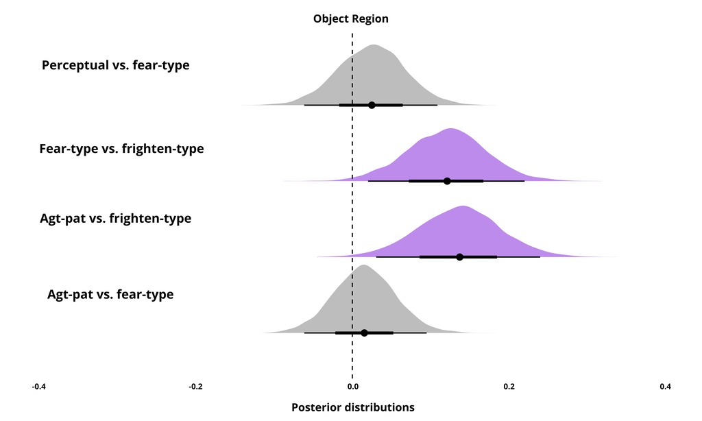

**Results of Experiment 1**

Regression Path Duration

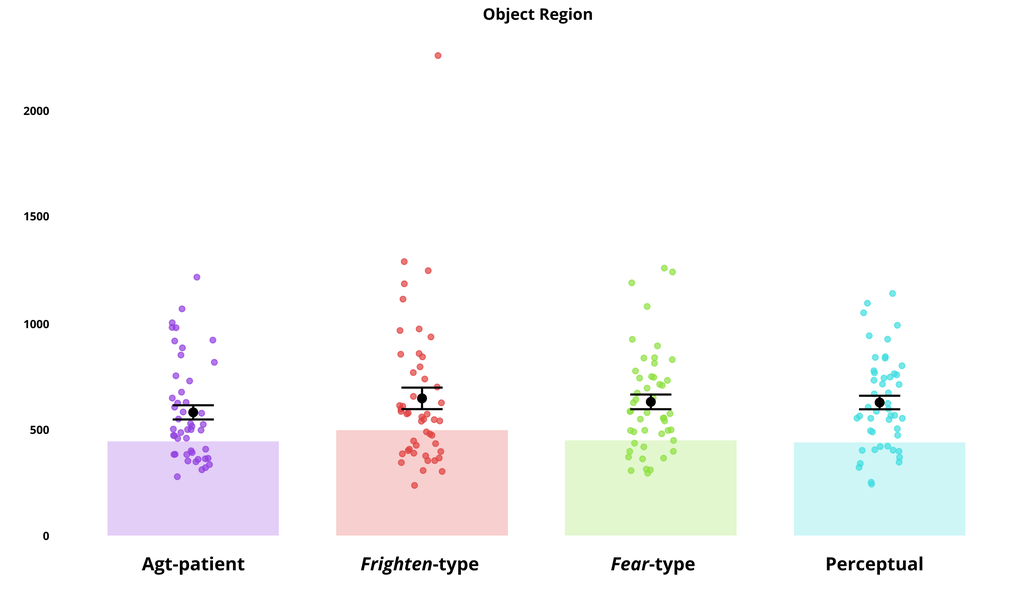

**Results of Experiment 1**

Total Duration

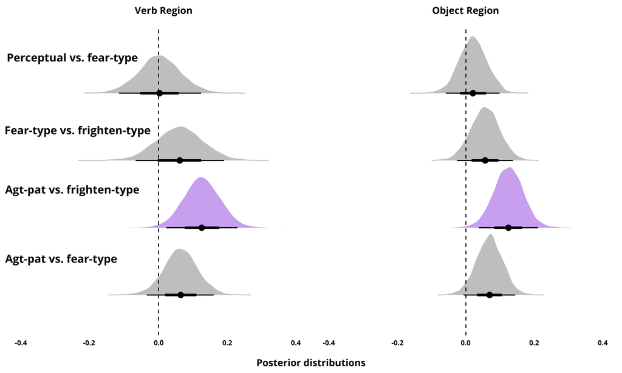

**Results of Experiment 1**

Total Duration

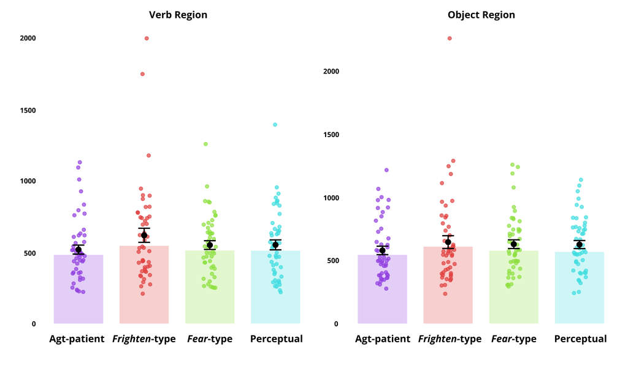

- RQ 1: Do psychological verbs elicit processing specificities?

RQ 1: Do psychological verbs elicit processing specificities?

Mary saw John

Mary feared John

Mary frightened John

**Psychological Verb Hypothesis**

Psychological Verbs

→

Psychological Verbs

→

Perceptual Verbs

→

*fear*-type = *frighten*-type

*fear*-type ≠ perceptual

**Non-Psychological Verb Hypothesis**

→

experiencer-theme

→

experiencer-theme

→

agent-experiencer

*fear*-type ≠ *frighten*-type

✓

*fear*-type = perceptual

✓

- RQ 2: Do experiencers exhibit specific processing correlates?

RQ 2: Do experiencers exhibit specific processing correlates?

Mary frightened John

Mary hit John

**Experiencer Role Hypothesis**

Agent-experiencer

→

Agent-patient

→

*frighten*-type = agent-patient

**Proto-Role Hypothesis**

→

proto-agent-proto-agent

→

proto-agent-proto-patient

*frighten*-type ≠ agent-patient

✓

**Competition**

# Experiment 2

- RQ 1: Does the number of proto-agent entailments of subjects modulate the processing correlates of competing structures?

Proto-Role Hypothesis

The similarity-based interference effect

↓

Lewis & Vasishth (2005); Nicenboim & Vasishth (2018); Van Dyke (2003)

Mary frightens John

↓

causation

sentience

volition

↓

sentience

The wind frightens John

↓

causation

↓

sentience

Competition

**Competition**

**Methods of Experiment 2**

50 Spanish native speakers

Eye-tracking reading experiment

40 experimental items and 80 fillers

2x2 repeated measure design

→

Verb Type

Subject Type

Conditions

Sentence Regions

Subject

Verb

Subject

Verb

Object

Post-object

Last-word

Type

Type

Region

Region

Region

Region

Region

Animate

*Frighten*-  
type

El marinero

**preocupó**

al vendedor

en el amplio  
puerto de

Bilbao.

Animate

Agent-  
patient

El marinero

**golpeó**

al vendedor

en el amplio  
puerto de

Bilbao.

Inanimate

*Frighten*-  
type

El viento

**preocupó**

al vendedor

en el amplio  
puerto de

Bilbao.

Inanimate

Agent-  
patient

El viento

**golpeó**

al vendedor

en el amplio  
puerto de

Bilbao.

**Results of Experiment 2**

Total Duration

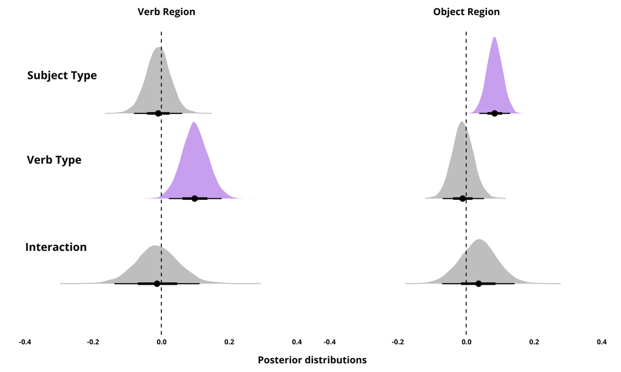

**Results of Experiment 2**

Total Duration

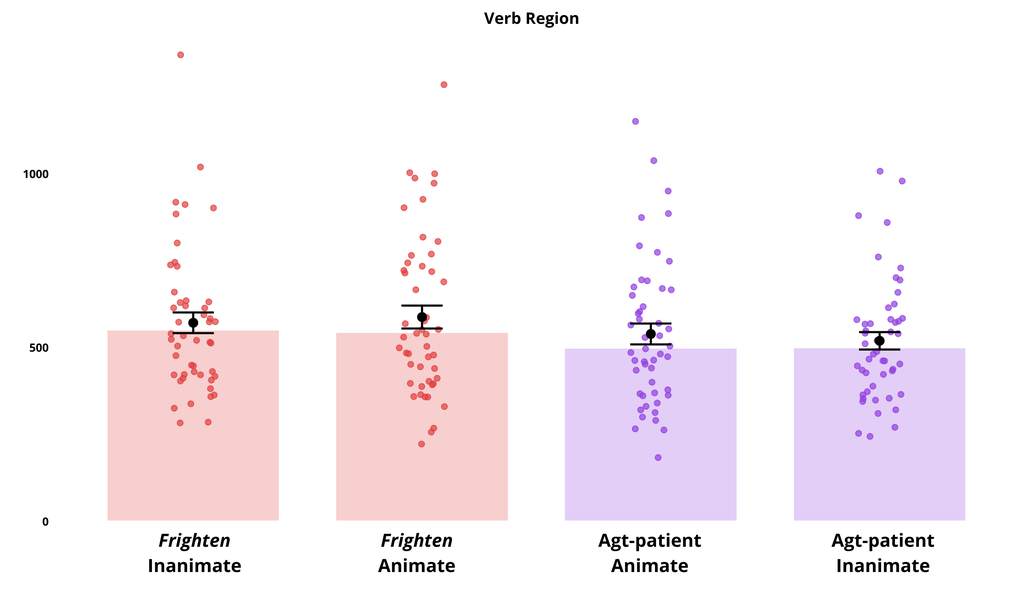

- RQ 1: Does the number of proto-agent entailments of subjects modulate the processing correlates of competing structures?

I did not find a modulation.

**Competition effect**

Mary frightens John

The wind frightens John

Mary hits John

The wind hits John

↓

causation

sentience

volition

↓

sentience

↓

causation

↓

sentience

↓

causation

sentience

volition

↓

∅

↓

causation

↓

∅

# Experiments 3 and 4

- RQ 1: Do experiencers display specific processing correlates, as agents and patients do, or do they show similar processing correlates as agents and different from patients?

**Experiencer Role Hypothesis**

Mary danced

Mary enjoyed

Mary stumbled

Agent

→

Experiencer

→

Patient

→

Recategorization

→

Experiencer

Patient

**Proto-Role Hypothesis**

→

Proto-agent

→

Proto-agent

→

Proto-patient

Recategorization

→

Proto-patient

**Methods of Experiment 3**

30 Spanish native speakers

Eye-tracking reading experiment

96 experimental items and 96 fillers

1x3 repeated measure design

→

Event Role Type

Conditions

Sentence Regions

Event Role

Subject

Pre-verb

Verb

Post-verb

Last-word

Type

Region

Region

Region

Region

Region

Agent

La conductora

el jueves

**se esforzó**

durante el

examen.

Experiencer

La conductora

el jueves

**se sorprendió**

durante el

examen.

Patient

La conductora

el jueves

**se desorientó**

durante el

examen.

**Results of Experiment 3**

Eye-tracking

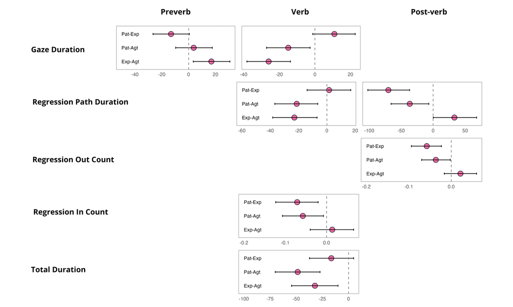

Eye-tracking results show:

- **Agents** and **experiencers** involved longer fixation times and regression counts than **patients** in late eye-tracking measures.
- Differences between **agents** and **experiencers** varied depending on the measure and region.

**Experiment 4**

30 Spanish native speakers

EEG reading experiment

96 experimental items and 96 fillers

1x3 repeated measure design

→

Event Role Type

**Results of Experiment 4**

ERPs

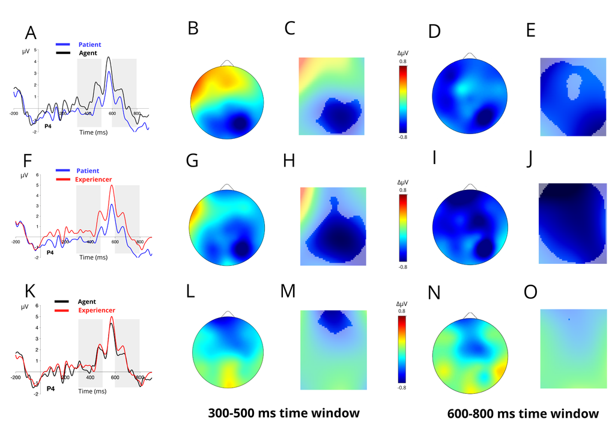

**Results of Experiment 4**

TFA

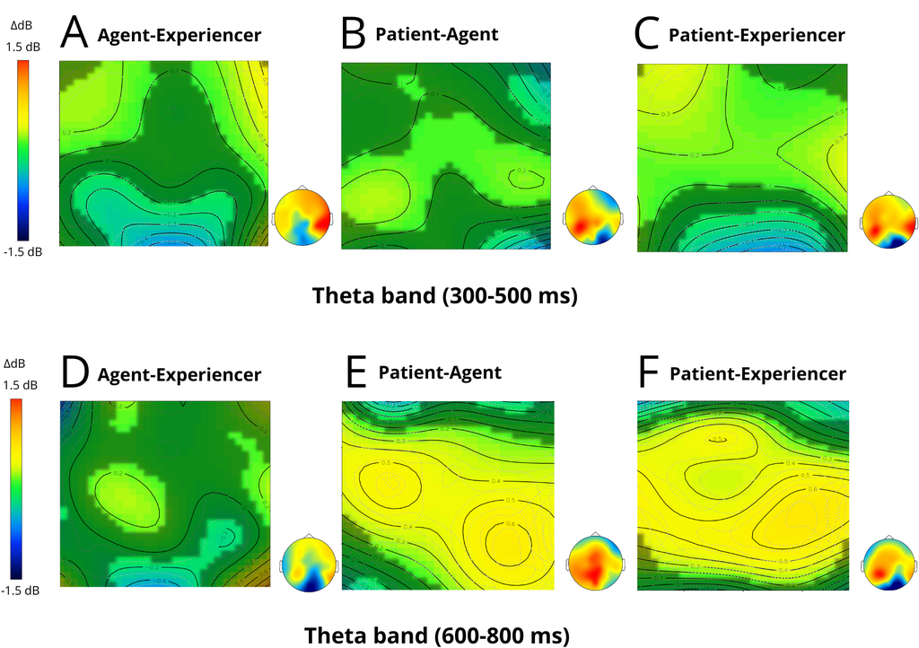

**Results of Experiment 4**

TFA

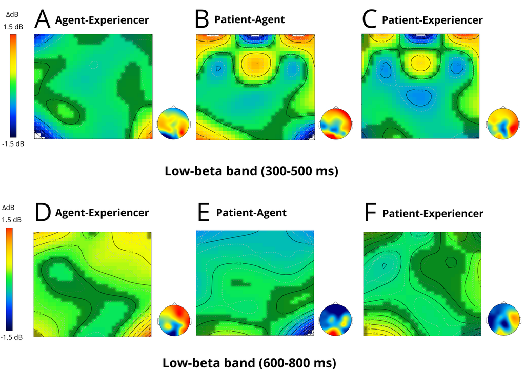

**Results of Experiment 4**

TFA

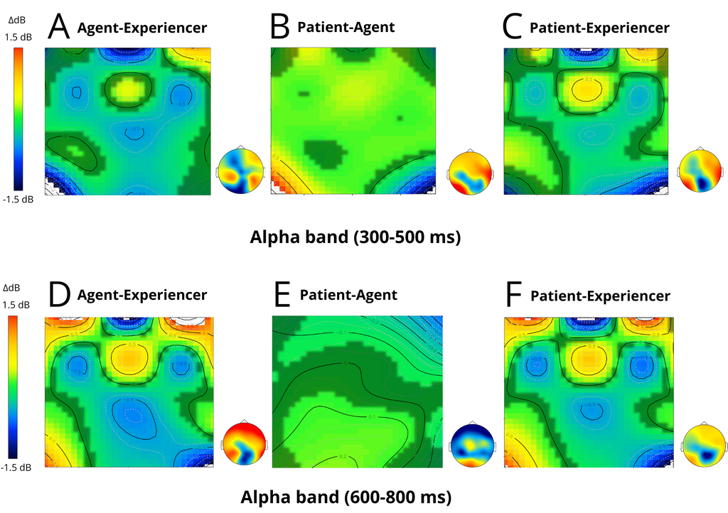

- RQ 1: Do experiencers display specific processing correlates, as agents and patients do, or do they show similar processing correlates as agents and different from patients?

**Experiencer Role Hypothesis**

Mary danced

Mary enjoyed

Mary stumbled

Agent

→

Experiencer

→

Patient

→

Recategorization

→

Experiencer

Patient

**Proto-Role Hypothesis**

→

Proto-agent

→

Proto-agent

→

Proto-patient

Recategorization

→

Proto-patient

✓

# General Discusssion

- *Frighten*-type verbs involve higher processing costs than both *fear*-type and agent-patient verbs.

**Non-psychological Verb Hypothesis and Proto-Role Hypothesis**

- *Fear*-type verbs exhibit similar processing correlates than perceptual verbs.

**Non-psychological Verb Hypothesis**

- Competition is not modulated by the number of proto-agent entailments of subjects.
- Agent and experiencer subjects of intransitive structures involve higher fixation times and regression counts compared to patient subjects in late eye-tracking measures.
- Patient subjects elicit an N400 component, a theta power increase, and an alpha and low-beta power decrease compared to both agent and experiencer subjects.

**Proto-Role Hypothesis**

No processing differences found between *fear*-type and perceptual verbs, whereas *frighten*-type verbs involve higher processing cost than both *fear*-type and agent-patient verbs.

Bornkessel et al. (2003); Do & Kaiser (2021); Gattei et al. (2015); Gattei et al. (2017); Wilson & Dillon (2022)

↓

**Non-psychological Verb Hypothesis**

**Proto-Role Hypothesis**

**Psychological Verb Hypothesis**

*Frighten*-type verbs

→

Misalignment

**Mary** frightened **John**

↓

theme

↓

experiencer

Agent > Experiencer > Theme

**Non-psychological Verb Hypothesis**

*Frighten*-type verbs

→

causation

**Mary** frightened **John**

↓

agent

↓

experiencer

Agent > Experiencer > Theme

**Non-psychological Verb Hypothesis**

*Frighten*-type verbs

→

causation

**Mary** frightened **John**

↓

Sentience

Volition

Causation

↓

Sentience

**Competition**

Agent and experiencer subjects behave similarly:

- An attentional preference to fixate **agents** and **experiencers**.
- A **recategorization** occured when encountering verbs selecting **patient role**, whereas it did not appear with verbs selecting agent or experiencer roles.
- Prototypicality effects between **agents** and **experiencers**.

**Proto-Role Hypothesis**

Evidence of **attentional preference** comes from:

- Higher fixation times of agents and experiencers compared to patients in late eye-tracking measures

Gómez-Vidal et al. (2022)

Evidence of **recategorization** comes from:

- Elicitation of an N400 effect of patient roles compared to both agents and experiencers.
- Patients elicited a power increase in the theta band.

An increase in theta band appears with unexpected words and with semantic processing demands.

Klimesch (1999), Rommers et al. (2017)

A power decrease in alpha band is related to a release of inhibition and in low beta to a change in the current cognitive set, to upcoming words that do not match the predicted word, or to semantic violations.

Isasi-Isasmendi et al. (2024)

Evidence of **prototypcality** comes from:

- Experiencers involved longer fixation times than agents in the preverbal region in the Gaze Duration measure, but in the verb region, experiencers showed shorter fixation times than agents and patients in the same measure.

Gaze Duration is associated with early word recognition and lexical access processes.

Conklin et al. (2018)

- Agents involved larger fixation times than patients and experiencers in the verb region. However, in the postverbal region, this pattern shifted and both agents and experiencers showed longer fixation times than patients.

A power decrease in alpha band is related to a release of inhibition and in low beta to a change in the current cognitive set, to upcoming words that do not match the predicted word, or to semantic violations.

The delayed increase for experiencers may reflect a later categorization as proto-agents, due to their unique proto-agent entailment — the one of sentience.

Dowty (1991)

# Conclusion

**Proto-Role Hypothesis**

**The girl** danced.

⇩

Agent

**The girl** enjoyed.

⇩

Agent

**Mila esker!**

# References

Belletti, A., & Rizzi, L. (1988). Psych-Verbs and θ-Theory. *Natural Language & Linguistic Theory*, *6*(3), 291–352. https://doi.org/10.1007/BF00133902

Bornkessel, I. (2002). *The Argument Dependency Model: A neurocognitive approach to incremental interpretation* [PhD thesis]. University of Leipzig.

Bornkessel, I., Schlesewsky, M., & Friederici, A. D. (2003). Eliciting thematic reanalysis effects: The role of syntax-independent information during parsing. *Language and Cognitive Processes*, *18*(3), 269–298. https://doi.org/10.1080/01690960244000018

Chapin, P. G. (1967). *On the syntax of word-derivation in English* [PhD thesis]. Massachusetts Institute of Technology.

Conklin, K., Pellicer-Sánchez, A., & Carrol, G. (2018). *Eye-Tracking: A guide for applied linguistics research*. Cambridge University Press. https://doi.org/10.1017/9781108233279

Do, M. L., & Kaiser, E. (2021). Sentence formulation is easier when thematic and syntactic prominence align: Evidence from psych verbs. *Language, Cognition and Neuroscience*, *37*(5), 648–670. https://doi.org/10.1080/23273798.2021.2008458

Dowty, D. (1991). Thematic proto-roles and argument selection. *Language*, *67*(3), 547–619. https://doi.org/10.1353/lan.1991.0021

Fillmore, C. J. (1968). The case for case. In E. Bach & R. T. Harms (Eds.), *Universals in linguistic theory* (pp. 1–88).

Fillmore, C. J. (1971). Some problems for case grammar. In R. J. O’Brien (Ed.), *Report of the 22nd annual round table meeting on linguistics and language studies* (pp. 35–56). Georgetown University Press.

Foley, W. A., & Van Valin, R. D. (1984). *Functional syntax and universal grammar*. Cambridge University Press.

Gattei, C. A., Sevilla, Y., Tabullo, Á. J., Wainselboim, A. J., París, L. A., & Shalom, D. E. (2017). Prominence in Spanish sentence comprehension: An eye-tracking study. *Language, Cognition and Neuroscience*, *33*(5), 587–607. https://doi.org/10.1080/23273798.2017.1397278

Gattei, C. A., Tabullo, Á., París, L., & Wainselboim, A. J. (2015). The role of prominence in Spanish sentence comprehension: An ERP study. *Brain and Language*, *150*, 22–35. https://doi.org/10.1016/j.bandl.2015.08.001

Gómez-Vidal, B., Arantzeta, M., Laka, J. P., & Laka, I. (2022). Subjects are not all alike: Eye-tracking the agent preference in Spanish. *PLOS ONE*, *17*(8). https://doi.org/10.1371/journal.pone.0272211

Grimshaw, J. (1990). *Argument structure*. MIT Press.

Haupt, F. S., Schlesewsky, M., Roehm, D., Friederici, A. D., & Bornkessel-Schlesewsky, I. (2008). The status of subject–object reanalyses in the language comprehension architecture. *Journal of Memory and Language*, *59*(1), 54–96. https://doi.org/10.1016/j.jml.2008.02.003

Isasi-Isasmendi, A., Sauppe, S., Andrews, C., Laka, I., Meyer, M., & Bickel, B. (2024). Incremental sentence processing is guided by a preference for agents: EEG evidence from Basque. *Language, Cognition and Neuroscience*, *39*(1), 76–97. https://doi.org/10.1080/23273798.2023.2250023

Jackendoff, R. (1990). *Semantic structures*. MIT Press.

Klimesch, W. (1999). EEG alpha and theta oscillations reflect cognitive and memory performance: A review and analysis. *Brain Research Reviews*, *29*(2-3), 169–195. https://doi.org/10.1016/S0165-0173(98)00056-3

Levin, B., & Rappaport Hovav, M. (2005). *Argument realization*. Cambridge University Press. https://doi.org/10.1017/CBO9780511610479

Lewis, R. L., & Vasishth, S. (2005). An activation‐based model of sentence processing as skilled memory retrieval. *Cognitive Science*, *29*(3), 375–419. https://doi.org/10.1207/s15516709cog0000_25

Nicenboim, B., & Vasishth, S. (2018). Models of retrieval in sentence comprehension: A computational evaluation using Bayesian hierarchical modeling. *Journal of Memory and Language*, *99*, 1–34. https://doi.org/10.1016/j.jml.2017.08.004

Postal, P. M. (1970). *Cross-over phenomena*. Holt, Rinehart and Winston.

Reinhart, T. (2000). *The theta system: Syntactic realization of verbal concepts*. Utrecht Institute of Linguistics, Utrecht University.

Rissman, L., & Majid, A. (2019). Thematic roles: Core knowledge or linguistic construct? *Psychonomic Bulletin & Review*, *26*(6), 1850–1869. https://doi.org/10.3758/s13423-019-01634-5

Rommers, J., Dickson, D. S., Norton, J. J. S., Wlotko, E. W., & Federmeier, K. D. (2017). Alpha and theta band dynamics related to sentential constraint and word expectancy. *Language, Cognition and Neuroscience*, *32*(5), 576–589. https://doi.org/10.1080/23273798.2016.1183799

Sauppe, S., Næss, Å., Roversi, G., Meyer, M., Bornkessel-Schlesewsky, I., & Bickel, B. (2023). An agent-first preference in a patient-first language during sentence comprehension. *Cognitive Science*, *47*(9, 9), e13340. https://doi.org/10.1111/cogs.13340

Van Dyke, J. (2003). Distinguishing effects of structure and decay on attachment and repair: A cue-based parsing account of recovery from misanalyzed ambiguities. *Journal of Memory and Language*, *49*(3), 285–316. https://doi.org/10.1016/S0749-596X(03)00081-0

Van Valin, R. D., & LaPolla, R. J. (1997). *Syntax structure, meaning, and function*. Cambridge University Press.

Wilson, M., & Dillon, B. (2022). Alignment between thematic roles and grammatical functions facilitates sentence processing: Evidence from experiencer verbs. *SSRN Electronic Journal*. https://doi.org/10.2139/ssrn.4235952